# Prediction of Median House Price for MSOA’s within the Greater London Area

Jason Liu

2024-07-09

```r
# install and load necessary packages
if(!require(ggplot2)) install.packages("tidyverse")
library(tidyverse)
if(!require(ggtext)) install.packages("ggtext")
library(ggtext)
if(!require(GGally)) install.packages("GGally")
library(GGally)
if(!require(MASS)) install.packages("MASS")
library(MASS)
select <- dplyr::select
if(!require(leaps)) install.packages("leaps")
library(leaps)
if(!require(texreg)) install.packages("texreg")
library(texreg)
if(!require(cvTools)) install.packages("cvTools")
library(cvTools)
if(!require(car)) install.packages("car")
library(car)
```

```r
# import the dataset
london <- read_csv("LondonData.csv", col_types = "cdffffdddddddd")
```

# Exploratory Data Analysis

## Understanding Inner vs Outer by Population Density and Political Alignment

### t-Test between Inner Status and Population Density

```r
t.test(Pop_Density ~ Inner, london)
```

```
##
##  Welch Two Sample t-test
##
## data:  Pop_Density by Inner
## t = 25.342, df = 630.32, p-value < 2.2e-16
## alternative hypothesis: true difference in means between group Inner and group Outer is not equal to 0
## 95 percent confidence interval:
##  6010.906 7020.734
## sample estimates:
## mean in group Inner mean in group Outer
##           12364.237            5848.417
```

### Violin Plots of Population Density by Inner Status and Political Alignment

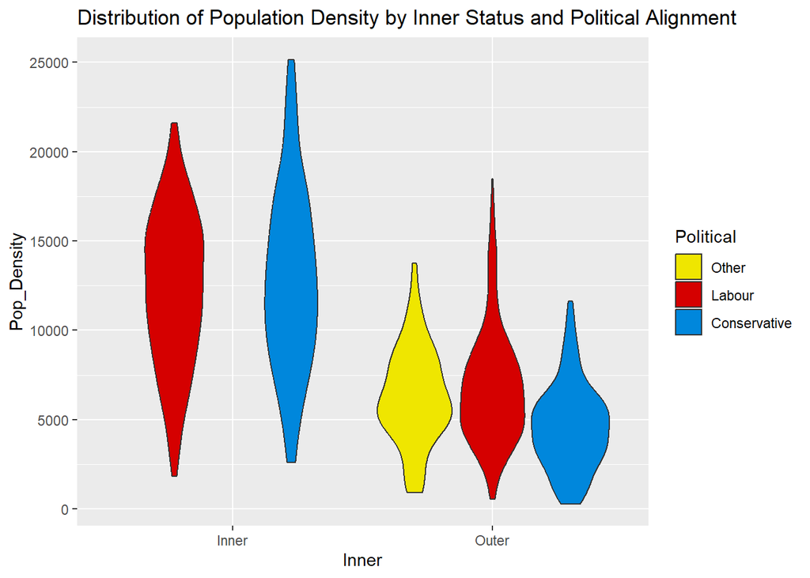

```r
colour_palette <- c("#EFE600", "#d50000", "#0087dc")
ggplot(london, aes(x = Inner, y = Pop_Density, fill = Political)) +
  scale_fill_manual(values = colour_palette) +
  geom_violin() +
  ggtitle("Distribution of Population Density by Inner Status and Political Alignment")
```

### Discussion *(213 words)*

The first thing to unpack with this dataset is that while there are many different variables, many of them probably provide similar information. The most apparent of these would be Inner and Pop_Density, as by definition, the Inner city is probably defined by central, higher density areas.  
It then makes sense to run a Welch’s Two Sample t-Test (assuming unequal variance) to test whether between Inner and Outer, the distributions each sample was drawn from have the same mean. Since it resulted in an extremely small p-value, we can say with a very high confidence level that they are definitely drawn from two distinct distributions, meaning that the Population Density is remarkably different between the Inner and Outer areas of London.  
The violin plots further visualise this significant difference in (sample) distribution. Together, they definitively show that there is a strong correlation between variables Inner and Pop_Density, so for any linear models, we should probably choose only one of them to use, or else risk issues caused by multicollinearity.  
Also, the different distributions for each Political Party show that somehow little to no subregions in Inner London favour any party considered “Other”, and that relatively speaking, the Inner city slightly favors the Conservative party more and the Outer favours Labour a bit more.

## Exploring BAME Demographics by Borough and Area

### 5-Number (+Mean) Summary Statistic of the Distribution of BAME

```r
summary(london$BAME)
```

```
##    Min. 1st Qu.  Median    Mean 3rd Qu.    Max.
##    3.81   23.71   37.35   39.42   53.62   93.86
```

### BAME Distribution split by Borough and Area

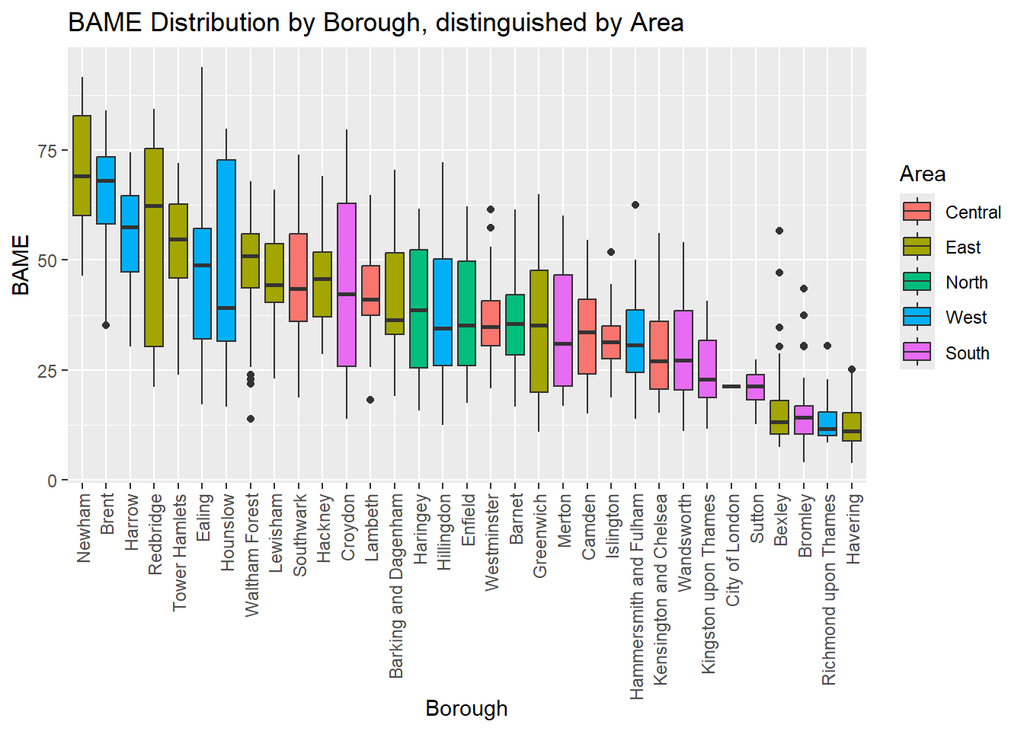

```r
# creates a tibble with each Borough's mean BAME and sorts in descending order
Borough_mean_BAME_desc <- london %>%
  group_by(Borough) %>%
  summarise(avg = mean(BAME)) %>%
  arrange(desc(avg))
# reorders the levels of Borough by descending mean BAME so it'll be shown as such in the plot
london_reordered <- london %>%
  mutate(Borough = factor(Borough, levels = Borough_mean_BAME_desc$Borough, ordered = TRUE))

ggplot(london_reordered, aes(x = Borough, y = BAME, fill = Area)) +
  geom_boxplot() +
  theme(axis.text.x = element_text(angle = 90, vjust = 0.5, hjust=1)) +
  ggtitle("BAME Distribution by Borough, distinguished by Area")
```

### Discussion *(187 words)*

The summary statistic shows that BAME ranges from 3.81 to 93.86 percent. By almost encompassing the entire possible range, this indicates that there’s a large amount of variety in the demographics between London’s different subregions.  
It’s also shown that the data has a positive skew, so we’d expect that any variable used to accurately group subregions by demographics would clearly include those with similarly high BAME values within the same group.  
As seen in our figure, grouping by Borough often leads to relatively tight distributions of BAME, meaning that Borough alone appears to reasonably represent the demographics of the subgroups within them. In other words, within each of London’s Boroughs, most subregions share pretty similar demographics.  
However, when considering Boroughs (and thus, subregions) within the same Area, they often don’t even have remotely similar BAME.  
As a result, when creating a model to predict values for subregions, we now know that considering the Borough of each subregion will itself be representative of many demographic factors, but attempting to further group by Area will lead to a loss in its relationship with BAME (and likely other demographic metrics).

## Assessing Viability of Boroughs as a useful grouping

### Summary Statistics evaluating Theoretical Performance for possible values of K for K-fold CV

```r
# using Borough without modification would prevent K-fold CV entirely since:
# sum(london$Borough == "City of London") == 1
# , which would always cause K-fold to fail,
# so in order to even consider using Borough, we'd need to drop that data point
london_dropped <- london %>%
  filter(Borough != "City of London")

# calculates the estimated probability that all levels (amount == i) of a factor manage to not fail R iterations of K-fold (failure caused by all points of a level being grouped into the same fold).
# input parameters:
#   n: numeric(1), total amount of data points
#   w: numeric(1), fold width, dependent on (n %/% K), must be integer
#   R: numeric(1), amount of iterations of K-fold
#   factor_counts: numeric(i), amount of each level
# output:
#   numeric(1), estimated probability that all runs of K-fold would pass, under the given parameters
calculate_prob_all_pass <- function(n, w, R, factor_counts){
  prob_all_pass <- 1
  for (count in factor_counts){
    # below code is numerically identical to:
    # factorial(w-1) / factorial(w-c) * factorial(n-c) / factorial(n-1)
    # , but numeric values stored using IEEE 754 roll over to 'Inf.' upon using significantly large factorial(),
    # so it's necessary to implement it in the below way to force simplification before storage
    prob_fail <- 1
    for (i in (w-1):(w-count + 1)){prob_fail <- prob_fail * i}
    for (i in (n-1):(n-count + 1)){prob_fail <- prob_fail / i}

    prob_pass <- 1 - prob_fail
    prob_all_pass <- prob_all_pass * prob_pass
  }
  prob_all_pass^R
}

# constructs final DataFrame, passing necessary values to run calculations
n <- nrow(london_dropped)
factor_counts <- unname(summary(london_dropped$Borough))[-1]
k_eval <- data.frame(K = 3:12) %>%
  mutate(R = 100 %/% K, w = n %/% K,
         prob_iters_fail = 1 - calculate_prob_all_pass(n, w, R, factor_counts),
         prob_samp_is_rep = 1 / choose(n, w))
k_eval
```

```
##     K  R   w prob_iters_fail prob_samp_is_rep
## 1   3 33 327    2.829156e-08    1.622719e-270
## 2   4 25 245    2.143300e-08    8.856440e-239
## 3   5 20 196    1.714640e-08    2.127637e-212
## 4   6 16 163    1.371712e-08    6.006388e-191
## 5   7 14 140    1.200248e-08    5.704846e-174
## 6   8 12 122    1.028784e-08    2.316603e-159
## 7   9 11 109    9.430520e-09    5.297040e-148
## 8  10 10  98    8.573200e-09    8.369961e-138
## 9  11  9  89    7.715880e-09    5.083322e-129
## 10 12  8  81    6.858560e-09    7.515042e-121
```

### Visualizing Amount of MSOA’s within Each Borough

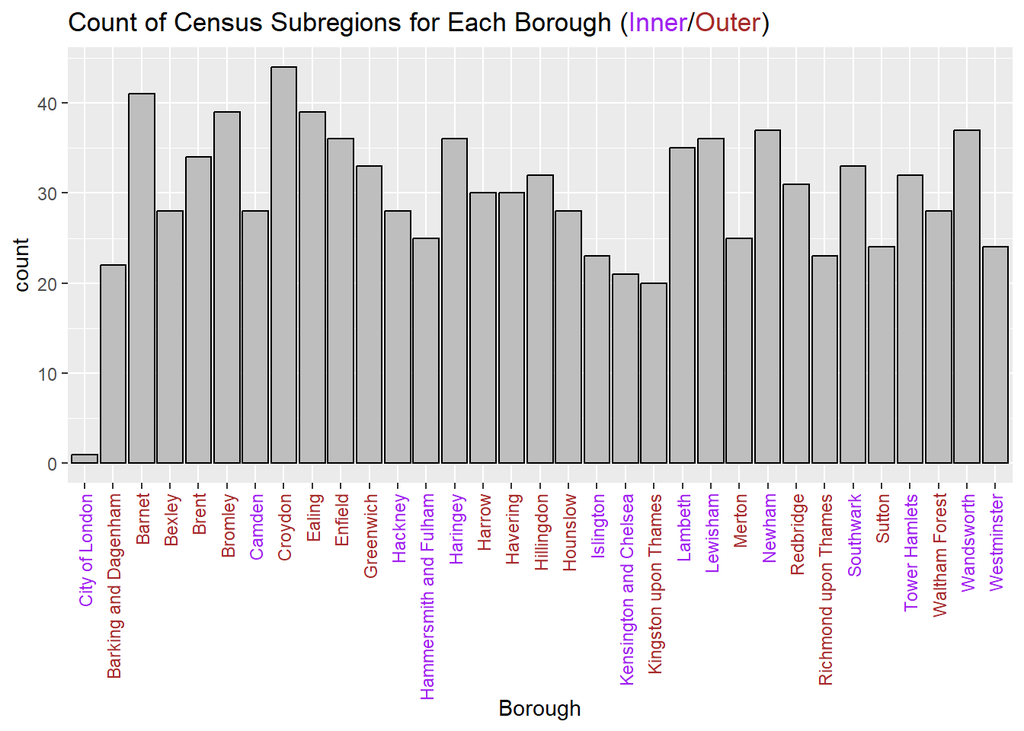

```r
# filters only for subregions from Inner Boroughs
london_inner_boroughs <- london %>%
  filter(Inner == "Inner") %>%
  group_by(Borough)
# creates a vector listing all the Inner Boroughs
inner_boroughs <- levels(london$Borough)[as.numeric(table(london_inner_boroughs$Borough)) != 0]

london %>%
  ggplot(aes(Borough)) +
  geom_bar(colour = "black", fill = "gray") +
  theme(axis.text.x = element_text(angle = 90, vjust = 0.5, hjust=1, colour = ifelse(levels(london$Borough) %in% inner_boroughs, 'purple', 'brown'))) +
  ggtitle("Count of Census Subregions for Each Borough (<span style = 'color: purple;'>Inner</span>/<span style = 'color: brown;'>Outer</span>)") +
  theme(plot.title = element_markdown())
```

### Discussion *(363 words)*

*Note: This discussion is a little longer, but the others are quite under. Due to the much more complex nature of this exploration, it was unavoidable.*

Since grouping by Area failed to accurately represent the many differences present between individual subgroups, we must instead consider using Borough as a key input parameter.  
The initial colour-coded labels in the figure indicate that Inner Boroughs don’t seem to consistently contain more or less subregions than Outer Boroughs.  
However, the much more apparent observation is that London has many Boroughs and that the Boroughs each contain largely differing amounts of subregions. This causes two main issues: that using Borough as a parameter can run a risk of overfitting our data, so it’s important to use K-fold cross validation effectively to check for this; and that K-fold will fail here since some Boroughs contain very few subregions, so if all of those ever fall within the same fold, a model will be tested for a categorical level it simply doesn’t contain.  
In fact, the current dataset has a 100% chance of this occurring since “City of London” contains only one datapoint, so it’s always fully contained within a fold. However, by removing the problematic datapoint, the odds of K-fold failing now is dependent on the value of K since larger K means smaller folds, leading to a lower chance that a whole Borough falls within one.  
Also, to get the most out of our actual split iterations (we’ll specify 100 for our purposes), we want to reduce the odds of repeating any given train/test split. Smaller K has more possible ways to split the dataset, so a lower chance of repeats.  
Since we want to minimize both of these values, it proved useful as a summary statistic to construct a table containing the values for each K we’d like to consider. The mathematical derivation of the formulas used to estimate the values are included below (the prob_samp_is_rep is just the odds during the second split, but it’s informatively no different and is actually comprehensible).  
The table indicates that choosing the value as K=8 appears to be best balance minimizing both values as decreasing to 7 sees a significant 17% increase in the failure probability and increasing to 9 sees a 229 billion times higher probability that any given sample is a repeat.

#### Derivation of Formula for *prob_iters_fail*

$n =$ count of data points; $w =$ width of fold, truncated to the nearest whole; $c =$ occurrences of the given level.
So to consider $P(l_1)$, the probability of any given level failing by our specified condition, we calculate:
$$P(l_1) = k (\frac{1}{k} \times \frac{w-1}{n-1}
\times \frac{w-2}{n-2} \times ... \times \frac{w-c+1}{n-c+1})$$
As whatever we consider the “first” value of the level must be in one of the K folds, then every following value needs to fall into one of the remaining spots within the width (one less each time) out of the total available spots (also decreasing each time), until the entire count of the level is exhausted.
So the total odds of one iteration (with $i$ different levels) failing would be:
$$P(L) = 1 - [(1- P(l_1)) \times (1-
P(l_2)) \times ... \times (1- P(l_i)]$$
Therefore, the odds of at least one of all the iterations ran failing would be:
$$1 - (1 - P(L)) ^ R$$

#### Derivation of Formula for *prob_samp_is_rep*

Given the already defined values, we can consider the total amount of possible train/test splits as $n \choose w$.
So, to calculate the odds of a train/test split being a repeat (for our purpose, the second time it’s sampled), we just do:
$$\frac{1}{n \choose w}$$

# Regression

## Approach and Discussion (899 Words)

*Note that for reasons quite apparent later on, it’s best for standardization of our figures to always use the london_dropped dataset, which has the only MSOA within the City of London removed.*

### Previewing Possible Relationships

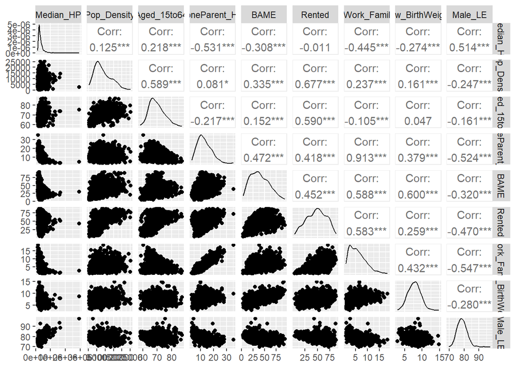

```r
london_dropped %>%
  select(-c(MSOA, Borough, Inner, Area, Political)) %>%
  ggpairs()
```

Looking closer, LoneParent_HH, BAME, NoWork_Families, LowBirthWeight, and Male_LE actually all appear to be highly correlated with one another.

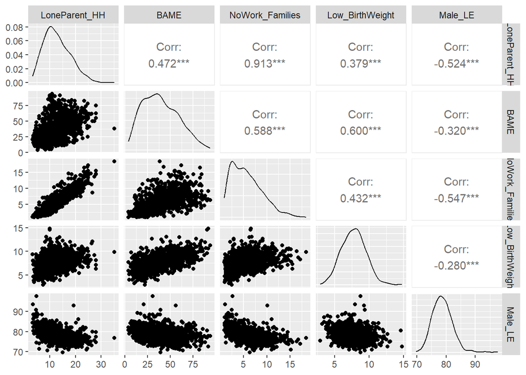

```r
london_dropped %>%
  select(c(LoneParent_HH, BAME, NoWork_Families, Low_BirthWeight, Male_LE)) %>%
  ggpairs()
```

Since these variables likely all provide similar information, it’s best for our model’s simplicity and correctness to only choose the most eligible of the five. The initial pairing plot seems to indicate that Male_LE may be a strong, linear, predictor for Median_HP.

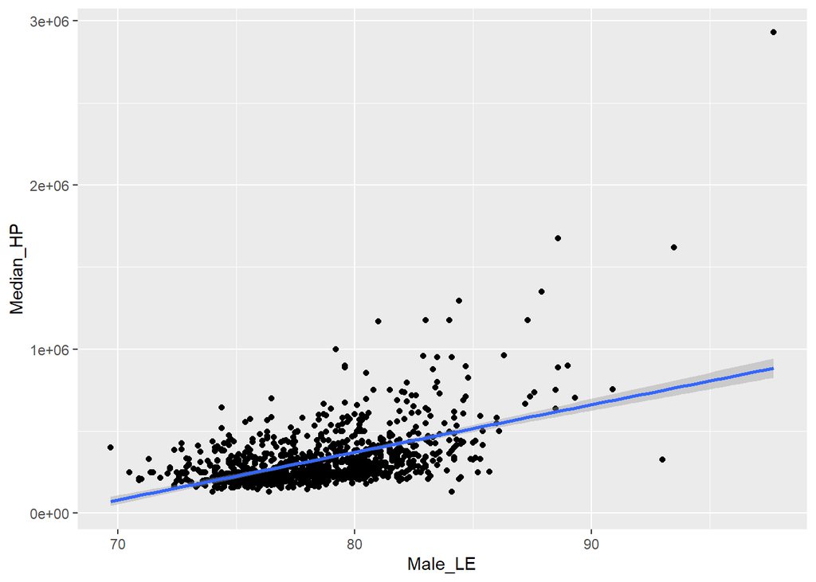

```r
ggplot(london_dropped, aes(x = Male_LE, y = Median_HP)) +
  geom_point() +
  geom_smooth(method='lm')
```

```r
summary(lm(Median_HP ~ Male_LE, data = london_dropped))
```

```
##
## Call:
## lm(formula = Median_HP ~ Male_LE, data = london_dropped)
##
## Residuals:
##     Min      1Q  Median      3Q     Max
## -421194  -93233  -33916   60454 2045106
##
## Coefficients:
##             Estimate Std. Error t value Pr(>|t|)
## (Intercept) -1946314     121780  -15.98   <2e-16 ***
## Male_LE        28979       1547   18.74   <2e-16 ***
## ---
## Signif. codes:  0 '***' 0.001 '**' 0.01 '*' 0.05 '.' 0.1 ' ' 1
##
## Residual standard error: 160300 on 980 degrees of freedom
## Multiple R-squared:  0.2638, Adjusted R-squared:  0.263
## F-statistic: 351.1 on 1 and 980 DF,  p-value: < 2.2e-16
```

From the scatterplot, it appears that the correlation between Male_LE and Median_HP is quite linear, and a R^2 of 0.26 is quite high for a single variable linear regression within such a complex application. Using Male_LE will probably be the most effective way to accurately represent this set of variables.

From the pairs plot, another set of variables that appear very highly correlated are: Pop_Density, Aged_15to64, and Rented.

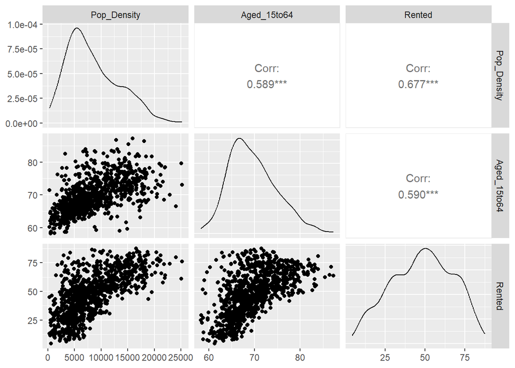

```r
london_dropped %>%
  select(c(Pop_Density, Aged_15to64, Rented)) %>%
  ggpairs()
```

Again, it’s probably best to just choose the most effective one to represent these values, or else we’re going to run into issues with multicollinearity.

The best of these appears to be Aged_15to64.

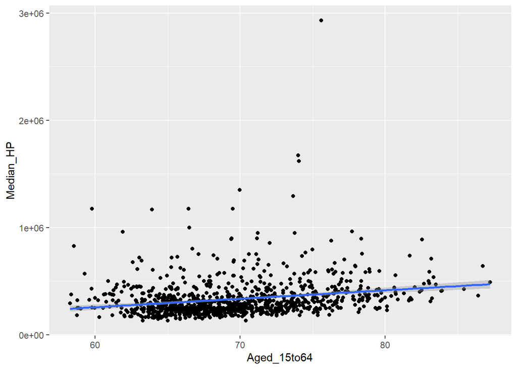

```r
ggplot(london_dropped, aes(x = Aged_15to64, y = Median_HP)) +
  geom_point() +
  geom_smooth(method='lm')
```

```r
summary(lm(Median_HP ~ Aged_15to64, data = london_dropped))
```

```
##
## Call:
## lm(formula = Median_HP ~ Aged_15to64, data = london_dropped)
##
## Residuals:
##     Min      1Q  Median      3Q     Max
## -206980  -96291  -49576   36111 2549677
##
## Coefficients:
##             Estimate Std. Error t value Pr(>|t|)
## (Intercept)  -214461      78568  -2.730  0.00645 **
## Aged_15to64     7870       1125   6.994 4.95e-12 ***
## ---
## Signif. codes:  0 '***' 0.001 '**' 0.01 '*' 0.05 '.' 0.1 ' ' 1
##
## Residual standard error: 182300 on 980 degrees of freedom
## Multiple R-squared:  0.04754,    Adjusted R-squared:  0.04657
## F-statistic: 48.91 on 1 and 980 DF,  p-value: 4.948e-12
```

Within the exploratory analysis, we’ve already found that using Borough is the most representative way to group the subregions by geographic area.

While using a factor with so many levels may raise concerns about possibly overfitting the data, we’ve already chosen the optimal value of K with which we can perform a sufficient amount of iterations to perform cross validation.

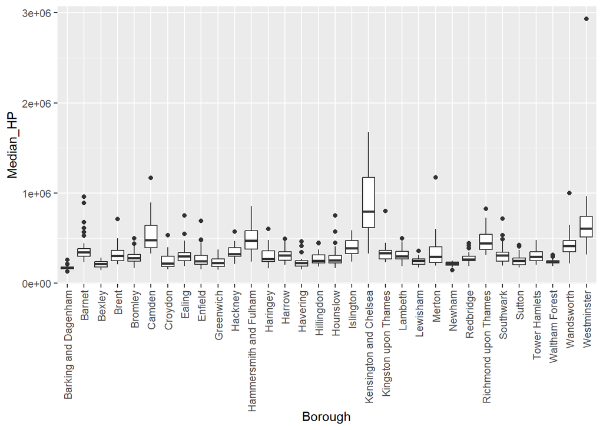

```r
ggplot(london_dropped, aes(x = Borough, y = Median_HP)) +
  geom_boxplot() +
  theme(axis.text.x = element_text(angle = 90, vjust = 0.5, hjust=1))
```

Just by examining the distribution of Median_HP within each Borough, we observe pretty tight distributions within each of them, besides Kensington and Chelsea (as this Borough just consistently contains unprecedented values for most variables). This means that just knowing the Borough of a subregion can give us pretty effective insight on the Median House Price. Due to the clear benefit this factor immediately provides us, even if some of its levels don’t prove to be statistically significant over the base level, its inclusion is well justified.

### Model 1: Intuitive Approach Model

From our examination of the dataset, the most intuitive way to create a model would be just to include the best representative variable from each of the 3 groups of variables, as described above.

```r
model1 <- lm(Median_HP ~ Borough + Male_LE + Aged_15to64, data = london_dropped)
summary(model1)
```

```
##
## Call:
## lm(formula = Median_HP ~ Borough + Male_LE + Aged_15to64, data = london_dropped)
##
## Residuals:
##     Min      1Q  Median      3Q     Max
## -736539  -53263  -10666   33938 1910531
##
## Coefficients:
##                               Estimate Std. Error t value Pr(>|t|)
## (Intercept)                   -1644354     139896 -11.754  < 2e-16 ***
## BoroughBarnet                   133712      33047   4.046 5.63e-05 ***
## BoroughBexley                   -16397      35352  -0.464 0.642877
## BoroughBrent                     94150      34398   2.737 0.006315 **
## BoroughBromley                   53035      33195   1.598 0.110450
## BoroughCamden                   312289      36442   8.570  < 2e-16 ***
## BoroughCroydon                   21591      32458   0.665 0.506077
## BoroughEaling                    97206      33459   2.905 0.003755 **
## BoroughEnfield                   57047      33580   1.699 0.089680 .
## BoroughGreenwich                 76442      34289   2.229 0.026026 *
## BoroughHackney                  155748      36203   4.302 1.87e-05 ***
## BoroughHammersmith and Fulham   244177      37892   6.444 1.85e-10 ***
## BoroughHaringey                 121121      34309   3.530 0.000435 ***
## BoroughHarrow                    55498      35177   1.578 0.114978
## BoroughHavering                  25422      34734   0.732 0.464405
## BoroughHillingdon                61987      34353   1.804 0.071483 .
## BoroughHounslow                  87133      35641   2.445 0.014677 *
## BoroughIslington                251231      38740   6.485 1.43e-10 ***
## BoroughKensington and Chelsea   529275      40258  13.147  < 2e-16 ***
## BoroughKingston upon Thames      86952      38828   2.239 0.025360 *
## BoroughLambeth                  135921      35437   3.836 0.000134 ***
## BoroughLewisham                  69009      34036   2.028 0.042888 *
## BoroughMerton                    96918      36845   2.630 0.008666 **
## BoroughNewham                    42859      34043   1.259 0.208353
## BoroughRedbridge                 52437      34632   1.514 0.130327
## BoroughRichmond upon Thames     212450      37340   5.690 1.70e-08 ***
## BoroughSouthwark                 94920      35675   2.661 0.007929 **
## BoroughSutton                    29313      36657   0.800 0.424112
## BoroughTower Hamlets            129859      35887   3.619 0.000312 ***
## BoroughWaltham Forest            67815      35515   1.909 0.056502 .
## BoroughWandsworth               204359      34950   5.847 6.88e-09 ***
## BoroughWestminster              370632      39404   9.406  < 2e-16 ***
## Male_LE                          22022       1468  15.002  < 2e-16 ***
## Aged_15to64                       1874       1068   1.755 0.079567 .
## ---
## Signif. codes:  0 '***' 0.001 '**' 0.01 '*' 0.05 '.' 0.1 ' ' 1
##
## Residual standard error: 123500 on 948 degrees of freedom
## Multiple R-squared:  0.5773, Adjusted R-squared:  0.5626
## F-statistic: 39.24 on 33 and 948 DF,  p-value: < 2.2e-16
```

### Model 2: Variable Selection by Statistical Significance

It’s a common approach to first try to run a multilinear regression model with every possible variable in it (besides those that are actual repeats) and then only keep the ones that are statistically significant.

```r
model_max <- lm(Median_HP ~ . - MSOA - Inner - Area - Political, data = london_dropped)
summary(model_max)
```

```
##
## Call:
## lm(formula = Median_HP ~ . - MSOA - Inner - Area - Political,
##     data = london_dropped)
##
## Residuals:
##     Min      1Q  Median      3Q     Max
## -524919  -49944   -7439   36115 1961007
##
## Coefficients:
##                                 Estimate Std. Error t value Pr(>|t|)
## (Intercept)                   -2.403e+05  1.729e+05  -1.390 0.164912
## BoroughBarnet                  1.074e+05  3.095e+04   3.470 0.000543 ***
## BoroughBexley                 -6.881e+04  3.345e+04  -2.057 0.039975 *
## BoroughBrent                   1.438e+05  3.418e+04   4.208 2.82e-05 ***
## BoroughBromley                -2.203e+04  3.154e+04  -0.699 0.485013
## BoroughCamden                  2.931e+05  3.610e+04   8.120 1.45e-15 ***
## BoroughCroydon                 5.279e+04  3.116e+04   1.694 0.090534 .
## BoroughEaling                  9.413e+04  3.158e+04   2.980 0.002955 **
## BoroughEnfield                 5.786e+04  3.075e+04   1.881 0.060217 .
## BoroughGreenwich               3.747e+04  3.173e+04   1.181 0.237921
## BoroughHackney                 1.898e+05  3.514e+04   5.403 8.32e-08 ***
## BoroughHammersmith and Fulham  2.582e+05  3.647e+04   7.082 2.78e-12 ***
## BoroughHaringey                1.308e+05  3.169e+04   4.128 3.98e-05 ***
## BoroughHarrow                  6.606e+04  3.470e+04   1.904 0.057247 .
## BoroughHavering               -6.674e+04  3.322e+04  -2.009 0.044813 *
## BoroughHillingdon              2.636e+04  3.233e+04   0.815 0.415080
## BoroughHounslow                7.722e+04  3.360e+04   2.298 0.021782 *
## BoroughIslington               2.444e+05  3.662e+04   6.674 4.23e-11 ***
## BoroughKensington and Chelsea  5.624e+05  4.027e+04  13.967  < 2e-16 ***
## BoroughKingston upon Thames    3.504e+04  3.600e+04   0.973 0.330676
## BoroughLambeth                 1.789e+05  3.412e+04   5.242 1.96e-07 ***
## BoroughLewisham                1.058e+05  3.299e+04   3.209 0.001379 **
## BoroughMerton                  8.465e+04  3.466e+04   2.442 0.014777 *
## BoroughNewham                  8.584e+04  3.350e+04   2.563 0.010546 *
## BoroughRedbridge               5.348e+04  3.301e+04   1.620 0.105541
## BoroughRichmond upon Thames    1.206e+05  3.528e+04   3.420 0.000654 ***
## BoroughSouthwark               1.511e+05  3.481e+04   4.340 1.58e-05 ***
## BoroughSutton                 -2.719e+04  3.454e+04  -0.787 0.431270
## BoroughTower Hamlets           1.011e+05  3.531e+04   2.864 0.004280 **
## BoroughWaltham Forest          5.629e+04  3.328e+04   1.692 0.091066 .
## BoroughWandsworth              1.725e+05  3.271e+04   5.275 1.65e-07 ***
## BoroughWestminster             4.111e+05  3.890e+04  10.568  < 2e-16 ***
## Pop_Density                   -4.377e+00  1.226e+00  -3.569 0.000376 ***
## Aged_15to64                   -1.628e+03  1.350e+03  -1.206 0.228042
## LoneParent_HH                 -1.755e+04  2.498e+03  -7.027 4.05e-12 ***
## BAME                          -1.732e+03  3.770e+02  -4.594 4.93e-06 ***
## Rented                        -1.465e+00  5.445e+02  -0.003 0.997853
## NoWork_Families                1.292e+04  4.800e+03   2.692 0.007218 **
## Low_BirthWeight                2.494e+03  2.771e+03   0.900 0.368358
## Male_LE                        1.036e+04  1.671e+03   6.197 8.62e-10 ***
## ---
## Signif. codes:  0 '***' 0.001 '**' 0.01 '*' 0.05 '.' 0.1 ' ' 1
##
## Residual standard error: 111800 on 942 degrees of freedom
## Multiple R-squared:  0.6555, Adjusted R-squared:  0.6412
## F-statistic: 45.95 on 39 and 942 DF,  p-value: < 2.2e-16
```

Then, by choosing our variables, we get the following:

```r
model2 <- lm(Median_HP ~ Borough + Pop_Density + LoneParent_HH + BAME + NoWork_Families + Male_LE, data = london_dropped)
summary(model2)
```

```
##
## Call:
## lm(formula = Median_HP ~ Borough + Pop_Density + LoneParent_HH +
##     BAME + NoWork_Families + Male_LE, data = london_dropped)
##
## Residuals:
##     Min      1Q  Median      3Q     Max
## -531662  -50995   -6900   36295 1955289
##
## Coefficients:
##                                 Estimate Std. Error t value Pr(>|t|)
## (Intercept)                   -3.786e+05  1.350e+05  -2.805 0.005136 **
## BoroughBarnet                  1.081e+05  3.069e+04   3.522 0.000449 ***
## BoroughBexley                 -6.686e+04  3.335e+04  -2.005 0.045274 *
## BoroughBrent                   1.412e+05  3.354e+04   4.209 2.81e-05 ***
## BoroughBromley                -1.824e+04  3.144e+04  -0.580 0.562000
## BoroughCamden                  2.895e+05  3.394e+04   8.529  < 2e-16 ***
## BoroughCroydon                 5.344e+04  3.111e+04   1.718 0.086215 .
## BoroughEaling                  9.104e+04  3.142e+04   2.898 0.003845 **
## BoroughEnfield                 5.892e+04  3.046e+04   1.934 0.053401 .
## BoroughGreenwich               3.381e+04  3.143e+04   1.076 0.282330
## BoroughHackney                 1.840e+05  3.354e+04   5.487 5.25e-08 ***
## BoroughHammersmith and Fulham  2.483e+05  3.489e+04   7.114 2.22e-12 ***
## BoroughHaringey                1.244e+05  3.111e+04   4.000 6.83e-05 ***
## BoroughHarrow                  7.097e+04  3.450e+04   2.057 0.039916 *
## BoroughHavering               -6.128e+04  3.300e+04  -1.857 0.063607 .
## BoroughHillingdon              2.741e+04  3.230e+04   0.849 0.396196
## BoroughHounslow                7.350e+04  3.338e+04   2.202 0.027901 *
## BoroughIslington               2.337e+05  3.536e+04   6.609 6.47e-11 ***
## BoroughKensington and Chelsea  5.565e+05  3.775e+04  14.740  < 2e-16 ***
## BoroughKingston upon Thames    3.281e+04  3.594e+04   0.913 0.361588
## BoroughLambeth                 1.694e+05  3.270e+04   5.181 2.69e-07 ***
## BoroughLewisham                1.010e+05  3.239e+04   3.119 0.001868 **
## BoroughMerton                  8.099e+04  3.441e+04   2.354 0.018795 *
## BoroughNewham                  8.580e+04  3.286e+04   2.611 0.009179 **
## BoroughRedbridge               5.634e+04  3.294e+04   1.710 0.087517 .
## BoroughRichmond upon Thames    1.206e+05  3.495e+04   3.451 0.000584 ***
## BoroughSouthwark               1.424e+05  3.272e+04   4.351 1.50e-05 ***
## BoroughSutton                 -2.524e+04  3.451e+04  -0.731 0.464674
## BoroughTower Hamlets           9.669e+04  3.427e+04   2.821 0.004885 **
## BoroughWaltham Forest          5.720e+04  3.310e+04   1.728 0.084268 .
## BoroughWandsworth              1.632e+05  3.186e+04   5.122 3.67e-07 ***
## BoroughWestminster             4.013e+05  3.672e+04  10.929  < 2e-16 ***
## Pop_Density                   -4.812e+00  1.189e+00  -4.049 5.57e-05 ***
## LoneParent_HH                 -1.703e+04  2.459e+03  -6.926 8.02e-12 ***
## BAME                          -1.699e+03  3.515e+02  -4.835 1.55e-06 ***
## NoWork_Families                1.345e+04  4.161e+03   3.233 0.001268 **
## Male_LE                        1.086e+04  1.584e+03   6.853 1.31e-11 ***
## ---
## Signif. codes:  0 '***' 0.001 '**' 0.01 '*' 0.05 '.' 0.1 ' ' 1
##
## Residual standard error: 111800 on 945 degrees of freedom
## Multiple R-squared:  0.6544, Adjusted R-squared:  0.6413
## F-statistic: 49.71 on 36 and 945 DF,  p-value: < 2.2e-16
```

### Model 3: Stepwise Model Selection

```r
model_min <- lm(Median_HP ~ 1, data = london_dropped)
# model_max is already defined above
scp <- list(lower = model_min, upper = model_max)

model3 <- stepAIC(model_min,
                      direction = "forward",
                      scope = scp)
```

```
## Start:  AIC=23838.3
## Median_HP ~ 1
##
##                   Df  Sum of Sq        RSS   AIC
## + Borough         31 1.6302e+13 1.7883e+13 23264
## + LoneParent_HH    1 9.6364e+12 2.4549e+13 23515
## + Male_LE          1 9.0167e+12 2.5168e+13 23540
## + NoWork_Families  1 6.7635e+12 2.7421e+13 23624
## + BAME             1 3.2506e+12 3.0934e+13 23742
## + Low_BirthWeight  1 2.5632e+12 3.1622e+13 23764
## + Aged_15to64      1 1.6251e+12 3.2560e+13 23793
## + Pop_Density      1 5.3165e+11 3.3653e+13 23825
## <none>                          3.4185e+13 23838
## + Rented           1 3.8261e+09 3.4181e+13 23840
##
## Step:  AIC=23264.04
## Median_HP ~ Borough
##
##                   Df  Sum of Sq        RSS   AIC
## + LoneParent_HH    1 4.5828e+12 1.3301e+13 22975
## + NoWork_Families  1 4.1257e+12 1.3758e+13 23009
## + Male_LE          1 3.3872e+12 1.4496e+13 23060
## + Rented           1 2.9279e+12 1.4955e+13 23091
## + BAME             1 2.8980e+12 1.4985e+13 23092
## + Pop_Density      1 1.2176e+12 1.6666e+13 23197
## + Low_BirthWeight  1 7.1685e+11 1.7166e+13 23226
## <none>                          1.7883e+13 23264
## + Aged_15to64      1 3.8325e+09 1.7880e+13 23266
##
## Step:  AIC=22975.31
## Median_HP ~ Borough + LoneParent_HH
##
##                   Df  Sum of Sq        RSS   AIC
## + Male_LE          1 8.2728e+11 1.2473e+13 22914
## + Pop_Density      1 6.2470e+11 1.2676e+13 22930
## + BAME             1 4.3009e+11 1.2870e+13 22945
## + Aged_15to64      1 3.9775e+11 1.2903e+13 22948
## + Rented           1 2.4423e+11 1.3056e+13 22959
## <none>                          1.3301e+13 22975
## + Low_BirthWeight  1 2.6744e+10 1.3274e+13 22975
```

[output cut: 38 more lines]

```
##
##                   Df  Sum of Sq        RSS   AIC
## + Aged_15to64      1 2.5716e+10 1.1788e+13 22867
## <none>                          1.1813e+13 22867
## + Rented           1 8.9554e+09 1.1804e+13 22868
## + Low_BirthWeight  1 8.8117e+09 1.1805e+13 22868
##
## Step:  AIC=22866.73
## Median_HP ~ Borough + LoneParent_HH + Male_LE + BAME + Pop_Density +
##     NoWork_Families + Aged_15to64
##
##                   Df  Sum of Sq        RSS   AIC
## <none>                          1.1788e+13 22867
## + Low_BirthWeight  1 1.0142e+10 1.1777e+13 22868
## + Rented           1 1.5450e+07 1.1788e+13 22869
```

```r
summary(model3)
```

```
##
## Call:
## lm(formula = Median_HP ~ Borough + LoneParent_HH + Male_LE +
##     BAME + Pop_Density + NoWork_Families + Aged_15to64, data = london_dropped)
##
## Residuals:
##     Min      1Q  Median      3Q     Max
## -522163  -50461   -7230   36155 1967215
##
## Coefficients:
##                                 Estimate Std. Error t value Pr(>|t|)
## (Intercept)                   -2.260e+05  1.717e+05  -1.316 0.188475
## BoroughBarnet                  1.075e+05  3.067e+04   3.505 0.000478 ***
## BoroughBexley                 -6.958e+04  3.338e+04  -2.084 0.037405 *
## BoroughBrent                   1.435e+05  3.356e+04   4.275 2.11e-05 ***
## BoroughBromley                -2.148e+04  3.151e+04  -0.682 0.495519
## BoroughCamden                  2.948e+05  3.412e+04   8.639  < 2e-16 ***
## BoroughCroydon                 5.414e+04  3.110e+04   1.741 0.082005 .
## BoroughEaling                  9.328e+04  3.144e+04   2.967 0.003084 **
## BoroughEnfield                 6.040e+04  3.046e+04   1.983 0.047685 *
## BoroughGreenwich               3.643e+04  3.146e+04   1.158 0.247216
## BoroughHackney                 1.901e+05  3.379e+04   5.627 2.42e-08 ***
## BoroughHammersmith and Fulham  2.571e+05  3.541e+04   7.259 8.12e-13 ***
## BoroughHaringey                1.313e+05  3.146e+04   4.174 3.26e-05 ***
## BoroughHarrow                  6.840e+04  3.452e+04   1.981 0.047855 *
## BoroughHavering               -6.462e+04  3.306e+04  -1.955 0.050919 .
## BoroughHillingdon              2.763e+04  3.228e+04   0.856 0.392184
## BoroughHounslow                7.655e+04  3.343e+04   2.290 0.022242 *
## BoroughIslington               2.439e+05  3.605e+04   6.765 2.33e-11 ***
## BoroughKensington and Chelsea  5.622e+05  3.794e+04  14.818  < 2e-16 ***
## BoroughKingston upon Thames    3.459e+04  3.594e+04   0.962 0.336163
## BoroughLambeth                 1.794e+05  3.341e+04   5.370 9.94e-08 ***
## BoroughLewisham                1.060e+05  3.255e+04   3.255 0.001172 **
## BoroughMerton                  8.327e+04  3.443e+04   2.419 0.015766 *
## BoroughNewham                  8.889e+04  3.292e+04   2.701 0.007046 **
## BoroughRedbridge               5.404e+04  3.296e+04   1.639 0.101460
## BoroughRichmond upon Thames    1.198e+05  3.493e+04   3.429 0.000632 ***
## BoroughSouthwark               1.520e+05  3.339e+04   4.553 5.98e-06 ***
## BoroughSutton                 -2.677e+04  3.451e+04  -0.776 0.438031
## BoroughTower Hamlets           1.036e+05  3.459e+04   2.996 0.002808 **
## BoroughWaltham Forest          5.862e+04  3.309e+04   1.771 0.076834 .
## BoroughWandsworth              1.715e+05  3.237e+04   5.299 1.45e-07 ***
## BoroughWestminster             4.102e+05  3.722e+04  11.021  < 2e-16 ***
## LoneParent_HH                 -1.741e+04  2.472e+03  -7.043 3.61e-12 ***
## Male_LE                        1.031e+04  1.628e+03   6.333 3.71e-10 ***
## BAME                          -1.623e+03  3.553e+02  -4.569 5.55e-06 ***
## Pop_Density                   -4.418e+00  1.219e+00  -3.624 0.000306 ***
## NoWork_Families                1.284e+04  4.180e+03   3.071 0.002192 **
## Aged_15to64                   -1.588e+03  1.107e+03  -1.435 0.151595
## ---
## Signif. codes:  0 '***' 0.001 '**' 0.01 '*' 0.05 '.' 0.1 ' ' 1
##
## Residual standard error: 111700 on 944 degrees of freedom
## Multiple R-squared:  0.6552, Adjusted R-squared:  0.6417
## F-statistic: 48.48 on 37 and 944 DF,  p-value: < 2.2e-16
```

### Model 4: Variable Selection by Exhaustive Search

Making this method function in any useful way required forcing it to use all of Borough as an input or else it would try to pick and choose which levels it wanted.

```r
# this is performed on london (not london_dropped), but the results would just be offset by a set amount
regsubsets_out <- regsubsets( Median_HP ~ . - MSOA - Inner - Area - Political,
                             data = london,
                             nbest = 1,
                             nvmax = NULL,
                             force.in = c(rep(TRUE, 32), rep(FALSE, 8)),
                             force.out = NULL,
                             method = 'exhaustive')

# removes the different Borough levels (providing repeat info) and renames the remaining one in place
df_out <- as.data.frame(summary(regsubsets_out)$outmat)[32:40]
names(df_out)[names(df_out) == 'BoroughWestminster'] <- 'Borough'
df_out
```

```
##           Borough Pop_Density Aged_15to64 LoneParent_HH BAME Rented
## 33  ( 1 )       *                                     *
## 34  ( 1 )       *                                     *
## 35  ( 1 )       *                                     *    *
## 36  ( 1 )       *           *                         *    *
## 37  ( 1 )       *           *                         *    *
## 38  ( 1 )       *           *           *             *    *
## 39  ( 1 )       *           *           *             *    *
## 40  ( 1 )       *           *           *             *    *      *
##           NoWork_Families Low_BirthWeight Male_LE
## 33  ( 1 )
## 34  ( 1 )                                       *
## 35  ( 1 )                                       *
## 36  ( 1 )                                       *
## 37  ( 1 )               *                       *
## 38  ( 1 )               *                       *
## 39  ( 1 )               *               *       *
## 40  ( 1 )               *               *       *
```

```r
which.max(summary(regsubsets_out)$adjr)
```

```
## [1] 6
```

The results indicate that 6 variables added onto Borough led to the most accurate model, making it the model with 38 variables. Constructing that model gives:

```r
# this uses london_dropped again, taking away the initial base level and making it 37 variables
model4 <- lm(Median_HP ~ Borough + Pop_Density + Aged_15to64 + LoneParent_HH + BAME + NoWork_Families + Male_LE, data = london_dropped)
summary(model4)
```

```
##
## Call:
## lm(formula = Median_HP ~ Borough + Pop_Density + Aged_15to64 +
##     LoneParent_HH + BAME + NoWork_Families + Male_LE, data = london_dropped)
##
## Residuals:
##     Min      1Q  Median      3Q     Max
## -522163  -50461   -7230   36155 1967215
##
## Coefficients:
##                                 Estimate Std. Error t value Pr(>|t|)
## (Intercept)                   -2.260e+05  1.717e+05  -1.316 0.188475
## BoroughBarnet                  1.075e+05  3.067e+04   3.505 0.000478 ***
## BoroughBexley                 -6.958e+04  3.338e+04  -2.084 0.037405 *
## BoroughBrent                   1.435e+05  3.356e+04   4.275 2.11e-05 ***
## BoroughBromley                -2.148e+04  3.151e+04  -0.682 0.495519
## BoroughCamden                  2.948e+05  3.412e+04   8.639  < 2e-16 ***
## BoroughCroydon                 5.414e+04  3.110e+04   1.741 0.082005 .
## BoroughEaling                  9.328e+04  3.144e+04   2.967 0.003084 **
## BoroughEnfield                 6.040e+04  3.046e+04   1.983 0.047685 *
## BoroughGreenwich               3.643e+04  3.146e+04   1.158 0.247216
## BoroughHackney                 1.901e+05  3.379e+04   5.627 2.42e-08 ***
## BoroughHammersmith and Fulham  2.571e+05  3.541e+04   7.259 8.12e-13 ***
## BoroughHaringey                1.313e+05  3.146e+04   4.174 3.26e-05 ***
## BoroughHarrow                  6.840e+04  3.452e+04   1.981 0.047855 *
## BoroughHavering               -6.462e+04  3.306e+04  -1.955 0.050919 .
## BoroughHillingdon              2.763e+04  3.228e+04   0.856 0.392184
## BoroughHounslow                7.655e+04  3.343e+04   2.290 0.022242 *
## BoroughIslington               2.439e+05  3.605e+04   6.765 2.33e-11 ***
## BoroughKensington and Chelsea  5.622e+05  3.794e+04  14.818  < 2e-16 ***
## BoroughKingston upon Thames    3.459e+04  3.594e+04   0.962 0.336163
## BoroughLambeth                 1.794e+05  3.341e+04   5.370 9.94e-08 ***
## BoroughLewisham                1.060e+05  3.255e+04   3.255 0.001172 **
## BoroughMerton                  8.327e+04  3.443e+04   2.419 0.015766 *
## BoroughNewham                  8.889e+04  3.292e+04   2.701 0.007046 **
## BoroughRedbridge               5.404e+04  3.296e+04   1.639 0.101460
## BoroughRichmond upon Thames    1.198e+05  3.493e+04   3.429 0.000632 ***
## BoroughSouthwark               1.520e+05  3.339e+04   4.553 5.98e-06 ***
## BoroughSutton                 -2.677e+04  3.451e+04  -0.776 0.438031
## BoroughTower Hamlets           1.036e+05  3.459e+04   2.996 0.002808 **
## BoroughWaltham Forest          5.862e+04  3.309e+04   1.771 0.076834 .
## BoroughWandsworth              1.715e+05  3.237e+04   5.299 1.45e-07 ***
## BoroughWestminster             4.102e+05  3.722e+04  11.021  < 2e-16 ***
## Pop_Density                   -4.418e+00  1.219e+00  -3.624 0.000306 ***
## Aged_15to64                   -1.588e+03  1.107e+03  -1.435 0.151595
## LoneParent_HH                 -1.741e+04  2.472e+03  -7.043 3.61e-12 ***
## BAME                          -1.623e+03  3.553e+02  -4.569 5.55e-06 ***
## NoWork_Families                1.284e+04  4.180e+03   3.071 0.002192 **
## Male_LE                        1.031e+04  1.628e+03   6.333 3.71e-10 ***
## ---
## Signif. codes:  0 '***' 0.001 '**' 0.01 '*' 0.05 '.' 0.1 ' ' 1
##
## Residual standard error: 111700 on 944 degrees of freedom
## Multiple R-squared:  0.6552, Adjusted R-squared:  0.6417
## F-statistic: 48.48 on 37 and 944 DF,  p-value: < 2.2e-16
```

Note that this is entirely identical to Model 3, so for our comparison, we’ll just refer to them together as Model 3. This does also add some extra credibility to this model as it was reached in two separate ways.

### Comparing The Models

Let’s start by just considering some basic summary statistics.

```r
screenreg(list(model1, model2, model3))
```

```
##
## ==============================================================================
##                                Model 1          Model 2         Model 3
## ------------------------------------------------------------------------------
## (Intercept)                    -1644353.48 ***  -378561.43 **   -226015.43
##                                 (139896.34)     (134962.42)     (171737.20)
## BoroughBarnet                    133712.16 ***   108089.73 ***   107522.69 ***
##                                  (33047.24)      (30689.14)      (30674.49)
## BoroughBexley                    -16397.36       -66855.96 *     -69581.16 *
##                                  (35352.21)      (33348.69)      (33384.06)
## BoroughBrent                      94149.46 **    141165.03 ***   143452.15 ***
##                                  (34397.86)      (33538.58)      (33557.66)
## BoroughBromley                    53034.80       -18240.32       -21482.86
##                                  (33195.12)      (31444.54)      (31508.05)
## BoroughCamden                    312289.43 ***   289454.60 ***   294758.97 ***
##                                  (36441.68)      (33937.39)      (34119.19)
## BoroughCroydon                    21591.33        53436.53        54144.88
##                                  (32457.88)      (31112.95)      (31099.44)
## BoroughEaling                     97206.31 **     91043.03 **     93275.10 **
##                                  (33459.01)      (31417.95)      (31438.85)
## BoroughEnfield                    57047.07        58919.46        60402.81 *
##                                  (33580.24)      (30463.70)      (30464.18)
## BoroughGreenwich                  76442.14 *      33807.32        36430.05
##                                  (34289.29)      (31427.83)      (31463.35)
## BoroughHackney                   155748.05 ***   184021.34 ***   190115.95 ***
##                                  (36202.51)      (33537.59)      (33786.77)
## BoroughHammersmith and Fulham    244176.49 ***   248255.74 ***   257078.50 ***
##                                  (37891.87)      (34894.76)      (35412.96)
## BoroughHaringey                  121120.93 ***   124437.23 ***   131341.25 ***
##                                  (34309.45)      (31110.48)      (31463.03)
## BoroughHarrow                     55497.79        70973.69 *      68398.55 *
##                                  (35177.33)      (34495.84)      (34523.18)
## BoroughHavering                   25422.03       -61280.60       -64623.86
##                                  (34733.90)      (32997.85)      (33061.55)
## BoroughHillingdon                 61987.19        27414.03        27632.54
##                                  (34353.03)      (32296.62)      (32278.89)
## BoroughHounslow                   87132.62 *      73502.72 *      76549.15 *
##                                  (35641.09)      (33378.94)      (33427.72)
## BoroughIslington                 251230.54 ***   233711.30 ***   243886.20 ***
##                                  (38740.09)      (35364.24)      (36048.56)
```

[output cut: 31 more lines]

```
##                                   (1067.85)                       (1106.77)
## Pop_Density                                          -4.81 ***       -4.42 ***
##                                                      (1.19)          (1.22)
## LoneParent_HH                                    -17029.95 ***   -17411.09 ***
##                                                   (2459.01)       (2471.95)
## BAME                                              -1699.40 ***    -1623.19 ***
##                                                    (351.47)        (355.26)
## NoWork_Families                                   13451.71 **     12839.45 **
##                                                   (4160.97)       (4180.46)
## ------------------------------------------------------------------------------
## R^2                                   0.58            0.65            0.66
## Adj. R^2                              0.56            0.64            0.64
## Num. obs.                           982             982             982
## ==============================================================================
## *** p < 0.001; ** p < 0.01; * p < 0.05
```

All models have a quite high complexity, so the R^2 were all similarly reduced under adjustment. Model 3 has the best R^2, closely followed by Model 2. Also, one chosen variable, Aged_15to64 (present in Model 1 and Model 3), isn’t statistically significant.

While this does give us some insight, its absolutely necessary to check the accuracy under cross-validation. For efficiency, we’ll use the K value we optimized earlier.

*Note that while higher total iterations (achieved by higher R) would certainly be more effective, in order to keep the runtime reasonable, we’ll limit it to 100 for now*

```r
set.seed(0)
sqrt(mean(model1$residuals^2))
```

```
## [1] 121301.6
```

```r
cvFit(model1, data=london_dropped, y=london_dropped$Median_HP, K=8, R = 12)
```

```
## 8-fold CV results:
##       CV
## 127635.3
```

```r
set.seed(0)
sqrt(mean(model2$residuals^2))
```

```
## [1] 109680.7
```

```r
cvFit(model2, data=london_dropped, y=london_dropped$Median_HP, K=8, R = 12)
```

```
## 8-fold CV results:
##       CV
## 116414.1
```

```r
set.seed(0)
sqrt(mean(model3$residuals^2))
```

```
## [1] 109561.3
```

```r
cvFit(model3, data=london_dropped, y=london_dropped$Median_HP, K=8, R = 12)
```

```
## 8-fold CV results:
##       CV
## 116753.9
```

All 3 of our models have a small amount of overfitting, with Model 1 having the least (RMSE increased by 6333) in comparison to Model 2 (6733) and Model 3 (7192). However, even controlling for this, it’s still way more effective than if you were to not include Borough at all (shown below in a hypothetical Model 5)

```r
model5 <- lm(Median_HP ~ Pop_Density + Aged_15to64 + LoneParent_HH + BAME + NoWork_Families + Male_LE, data = london_dropped)
sqrt(mean(model5$residuals^2))
```

```
## [1] 137304.1
```

```r
cvFit(model5, data=london_dropped, y=london_dropped$Median_HP, K=8, R = 12)
```

```
## 8-fold CV results:
##       CV
## 140445.6
```

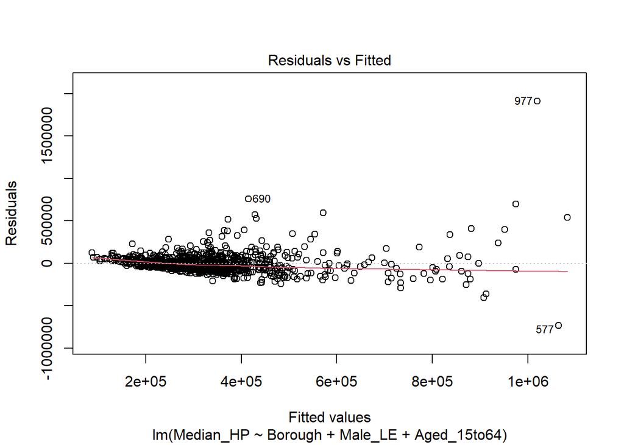

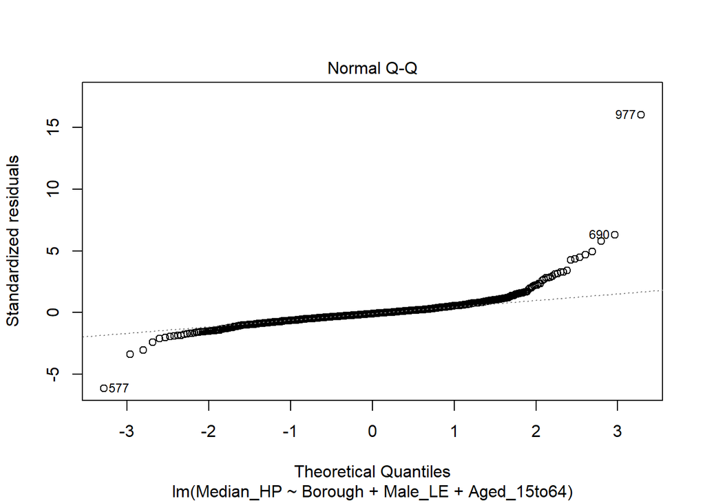

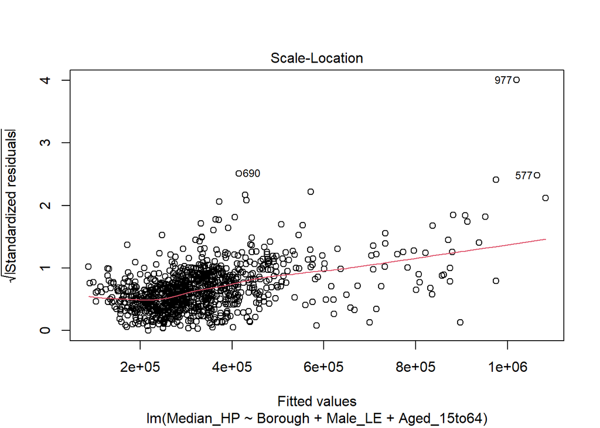

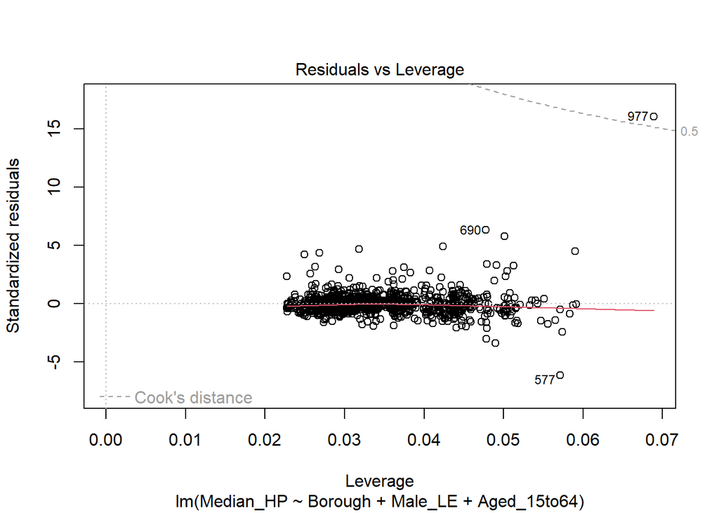

```r
plot(model1)
```

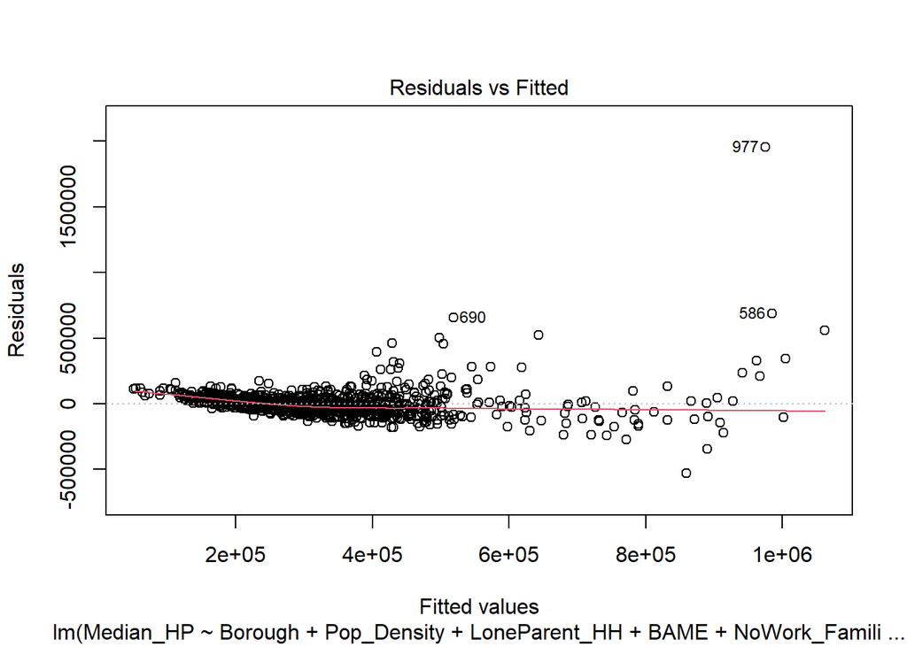

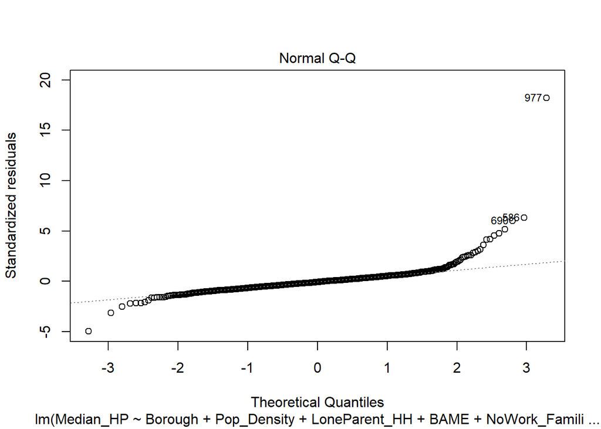

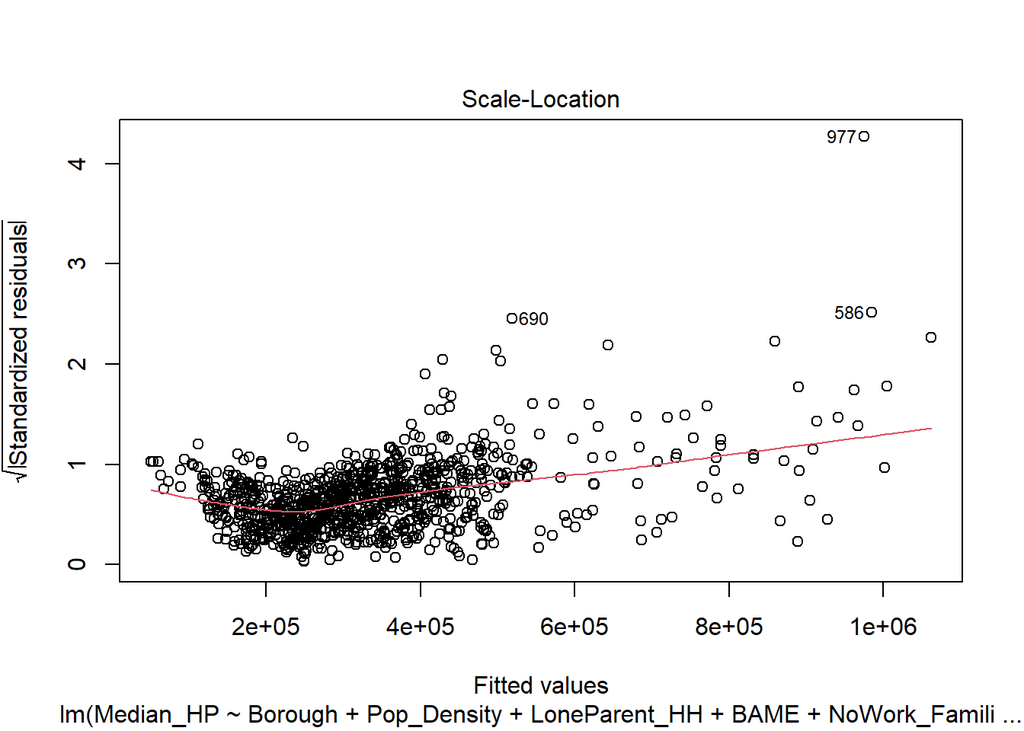

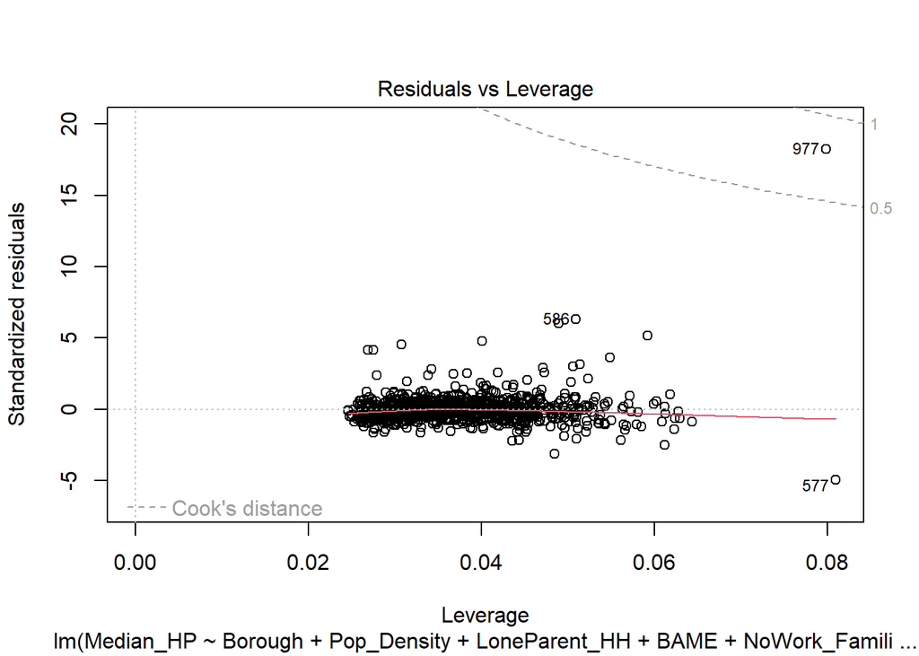

```r
plot(model2)
```

Model 2 and Model 3 had practically indistinguishable diagnostic plots, so I’ll save the space of showing Model 3’s.

```r
vif(model1)
```

```
##                 GVIF Df GVIF^(1/(2*Df))
## Borough     2.882985 31        1.017225
## Male_LE     1.518003  1        1.232073
## Aged_15to64 1.963191  1        1.401139
```

```r
vif(model2)
```

```
##                     GVIF Df GVIF^(1/(2*Df))
## Borough         16.39182 31        1.046142
## Pop_Density      2.62397  1        1.619867
## LoneParent_HH   12.06356  1        3.473263
## BAME             3.61512  1        1.901347
## NoWork_Families 14.23779  1        3.773299
## Male_LE          2.15614  1        1.468380
```

```r
vif(model3)
```

```
##                      GVIF Df GVIF^(1/(2*Df))
## Borough         22.636100 31        1.051603
## LoneParent_HH   12.204441  1        3.493485
## Male_LE          2.279993  1        1.509965
## BAME             3.697736  1        1.922950
## Pop_Density      2.764285  1        1.662614
## NoWork_Families 14.387635  1        3.793104
## Aged_15to64      2.574177  1        1.604424
```

The Variance Inflation Factors provide some startling insight as Models 2 and 3 display many extremely high VIF values. Our initial assessment of the variable relationships proves quite effective as many of these variables are quite correlated with eachother. Any attempt at removing multicollinear variables until this is resolved basically leads to the same selection as Model 1 (aside from Pop_Density and Aged_15to64 being interchangeable).

Since the presence of multicollinearity artificially inflates R^2 and RSE, it’s quite likely that the slightly higher fit values seen earlier were just the result of this.

So despite the various statistics showing mixed results on which model was the best, the actual qualities of the data and realm of assumptions that can be made confirm that Model 1 is the best model.

## Interpretation *(192 Words)*

By interpreting the coefficients present in the model, we can see that the model predicts that a subregion in Barking and Dagenham with 0 for both Male_LE and Aged_15to64 would have Median_HP of -£1644353.48 (which obviously isn’t really possible). Then, for each of the different Boroughs, it predicts varying increases of a couple more £10000’s in Median_HP, with some increasing within £200000-£300000. This clearly describes how different Boroughs have significantly different House Prices. The model also predicts an increase in Median_HP of £22021.91 for each percent increase in Male_LE and £1874.17 for each percent increase in Aged_15to64. It is quite interesting that there was no single variable that was by far the most indicative of Median House Price, but rather it amounted to a careful combination of variables representing demographic factors, regional density, and geographic location.

```r
errors <- predict(model1, london_dropped) - london_dropped$Median_HP
mean(abs(errors) <= 100000)
```

```
## [1] 0.8065173
```

The model proves to be over 80% accurate in predicting House Price within £100000.

While it’s certainly not perfect, the model’s predictions are quite accurate, and the insight it provides on the relationships between the covariates and Median House Price are useful to infer how changing factors within an area may influence the cost of housing.